# Prediction and Machine Learning

## Machine Learning

### Machine Learning: basics

For a given set of features, find a model that optimizes… something

Some examples:

- Predicting the outcome of an election or identifying likely voters
- Summarizing/grouping countries based on shared characteristics
- Identifying “populist” appeals in speeches and party manifestos.
- Using observed data to make inferences about missing data

### Machine Learning: some features

- More than a specific method, ML is distinguished by motivations, practices, and concerns
  - Prediction and optimization over explanation
  - Empiricism in evaluating models over theory
  - Problems like bias/variance trade-off and overcoming “the curse of dimensionality”
  - Distinct jargon: “features” (rather than variables), “supervised” and “unsupervised” methods etc.

### A prediction problem

- How will the incumbent party perform in the upcoming presidential election?
- Models like DA Hibbs’s “Bread and Peace” model make predictions based on things like economic performance.

| year | growth | vote | inc_party_candidate | other_candidate |
| --- | --- | --- | --- | --- |
| 1996 | 1.04 | 54.74 | Clinton | Dole |
| 2000 | 2.36 | 50.27 | Gore | Bush, Jr. |
| 2004 | 1.72 | 51.24 | Bush, Jr. | Kerry |
| 2008 | 0.10 | 46.32 | McCain | Obama |
| 2012 | 0.95 | 52.00 | Obama | Romney |

### A prediction problem

How should we assess the quality of results here? How would we compare the predictive power of two models?

```r
library(tidyverse)
data<-read_delim('https://raw.githubusercontent.com/avehtari/ROS-Examples/refs/heads/master/ElectionsEconomy/data/hibbs.dat',
               delim=' '
               )
model<-lm(vote ~ growth, data=data)

model
```

```
Call:
lm(formula = vote ~ growth, data = data)

Coefficients:
(Intercept)       growth
     46.248        3.061
```

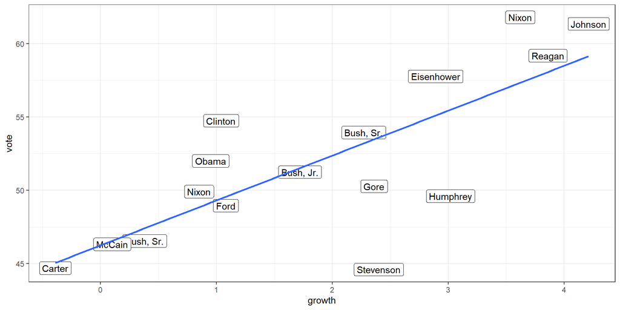

```r
ggplot(data, aes(x=growth, y=vote,
                 label=inc_party_candidate)) +
  geom_label() +
  theme_bw() +
  geom_smooth(method='lm', se=FALSE)
```

### A prediction problem

- Linear regression finds a set of coefficients (slopes) that minimizes the residual sum of squares. So the RSS for a given model is an obvious choice for a measure of model quality.

$$\hat{y} = x_i^T \beta$$

$$RSS = \sum (y - \hat{y})^2$$

```r
sum((data$vote -  cbind(1, data$growth) %*% coef(model))^2)
```

```
[1] 198.2727
```

```r
# OR

sum(residuals(model)^2)
```

```
[1] 198.2727
```

- All else equal, we could pick whatever model has the lowest RSS (or MSE or R^2, since these are based on the same thing)
- (Note that we could choose a different loss function, like the sum of absolute errors)

### How to cheat

Consider an alternate version of the model that includes polynomial terms for “growth” (growth + growth^2 + growth^3 …) up to the 10th degree.

- This isn’t necessarily a bad idea: sometimes the effect of X on Y is non-linear, and modeling this non-linearity is important for generating good predictions.
- But do we really trust that this is a better model?

```r
model_0 <-lm(vote ~ growth, data = data)         # original model
model_1<-lm(vote ~ poly(growth, 10), data=data) # new model
sum(residuals(model_0)^2)
```

```
[1] 198.2727
```

```r
sum(residuals(model_1)^2)
```

```
[1] 111.0174
```

### A prediction problem: bias/variance trade offs

Model 1 comes perilously close to playing “connect-the-dots”. Model like this are said to have “low bias” because the expected value of Y is close to observed values (at least within the known data)

… but they have high variance: small differences in the data will generate wildly different predictions, and they usually under perform when predicting new cases.

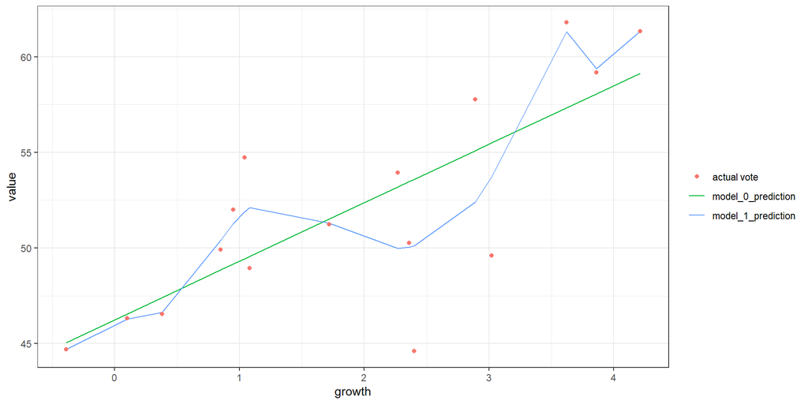

### A prediction problem: bias/variance trade offs

- This matters for how we build models, but it also matters for how we *assess* them: whenever possible, we want to evaluate performance on new data.
- In ML jargon:
  - Data used to fit a model is called “training” data.
  - Data used for evaluation is called “testing” data.

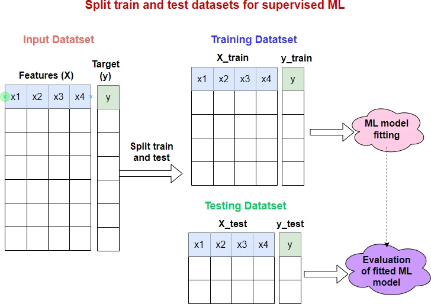

https://www.reneshbedre.com/blog/split-train-test-python.html

### Try it out

Randomly select one observation to serve as testing data. Fit both models on the remaining data and then calculate the squared residual for the “testing” observation. Take a look at your regression coefficients in both and see if you can diagnose a problem.

(note: you can use `predict(model, newdata=x)` to get model predictions for a new observation “x”)

```r
data<-read_delim('https://raw.githubusercontent.com/avehtari/ROS-Examples/refs/heads/master/ElectionsEconomy/data/hibbs.dat',
               delim=' '
               )
baseline_model<-lm(vote ~ growth ,data= data)
# example of predicting a new observation where growth = 4:

predict(baseline_model, newdata = data.frame(growth = 4))
```

```
       1
58.48976
```

### Try it out: Leave-one-out cross validation

There’s a lot of variability in our residuals here, but we can get a single summary statistic by repeating this process for every row and then aggregating our fit statistics.

This sort of training/testing split is referred to as “leave-one-out cross validation” (LOOCV)

```r
data<-read_delim('https://raw.githubusercontent.com/avehtari/ROS-Examples/refs/heads/master/ElectionsEconomy/data/hibbs.dat',
               delim=' '
               )

# example of leave-one-out cross validation
m0_sse<-0
m1_sse<-0

for(i in seq(nrow(data))){
  testing <- data[i,]
  training <- data[-i, ]

  model_0 <- lm(vote ~ growth, data=training)
  model_1 <- lm(vote ~ poly(growth, 10), data=training)

  m0_sse <-m0_sse + (testing$vote - predict(model_0, newdata=testing))^2
  m1_sse <-m1_sse + (testing$vote - predict(model_1, newdata=testing))^2
}
```

### LOOCV

Not great!

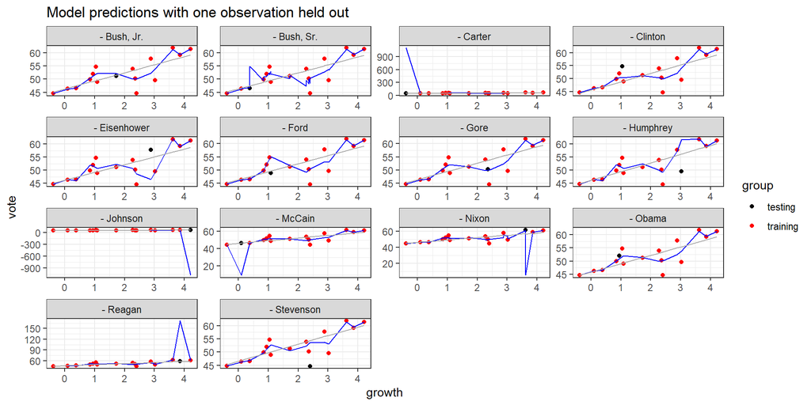

### Validation splits

- Leave-one-out cross validation is useful for small datasets, but computationally expensive for complex models.
- Some alternative evaluation setups are:
  - Simple train/test splits: holding out some % of data for testing
  - K-fold cross validation: splitting data into “K” folds and using K-1 for training
  - Boostrapped splits: create N data sets by sampling with replacement
  - Specialized splits for correlated data: such as stratified K-fold or time-series splits.

… in a later class we’ll use a unified framework for setting up splits like this, but for the moment, we’ll just do it using tools we’re already familiar with like loops and functions.

### Model-based methods for minimizing overfitting

- Some common sense would have gone a long way for the prior example, but the overfitting problem is ubiquitous even for well-thought-out analyses.
- The most popular ML methods often have some built-in protections that make them more robust to this issue, we’ll take a look at one example that’s based on a variation on the linear model.

### Ridge and Lasso models

- Ridge/Lasso regressions are one example of a ML model with some extra robustness against over-fitting.
- $\lambda$ represents some positive constant term that is set by the user (or chosen automatically)
- $\beta_j$ is a beta coefficient.
- Both lasso/ridge models apply “shrinkage”: they bias the (standardized) coefficients towards 0. The amount of shrinkage depends on $\lambda$.

OLS:

$$RSS = \sum^n_{i=1} (y - \hat{y})^2$$

Ridge model (L2 loss)

$$RSS_{L2} = \sum^n_{i=1} (y - \hat{y})^2 + \lambda \sum^P_{j=1}\beta^2_j$$

Lasso model (L1 loss):

$$RSS_{L1} = \sum^n_{i=1} (y - \hat{y})^2 + \lambda \sum^P_{j=1}\lvert\beta_j\rvert$$

### Ridge and Lasso models

Lasso model:

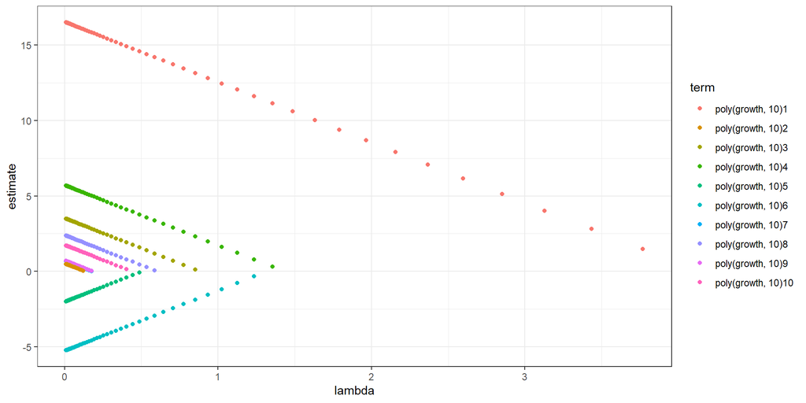

Ridge model:

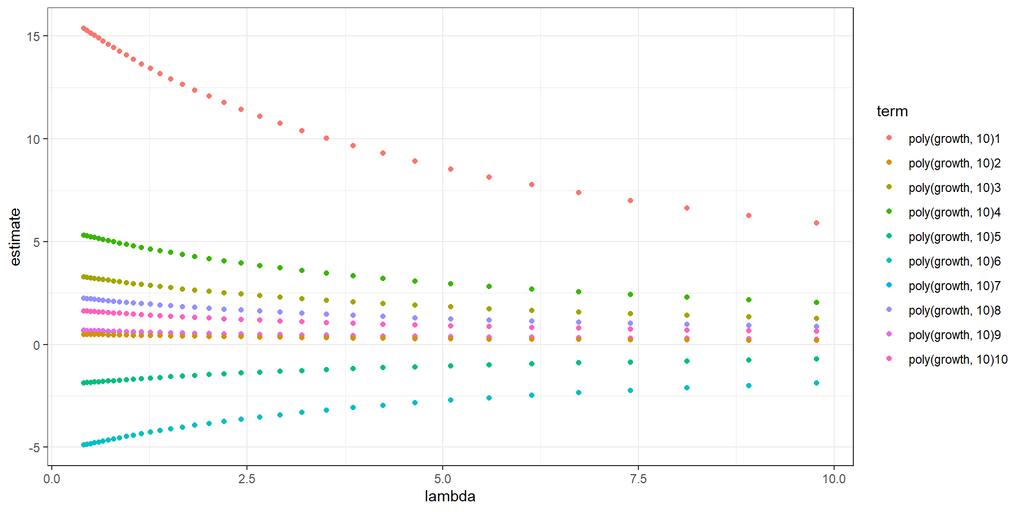

### Elastic net regularization

Elastic net models attempt a compromise between L1/L2 loss. $\alpha=0$ would give just the ridge penalty, $\alpha=1$ results in the lasso penalty. Anything in between is a mixture of the two.

$$(1-\alpha)/2 \lvert\lvert\beta\rvert\rvert^2 + \alpha \lvert\lvert\beta\rvert\rvert$$

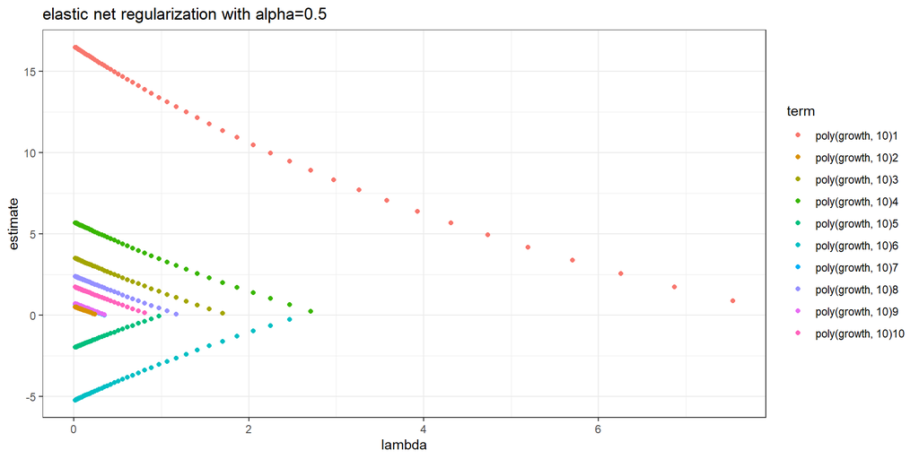

### Elastic net regularization

Applying this to the previous presidential race model, we can see most of the coefficient values have shrunk to zero, except for the 1st degree polynomial for economic growth:

```r
library(glmnet)

# glmnet only works with matrices, unfortunately
polynomials<- as.matrix(poly(data$growth, 10))


alpha_model<-glmnet(x=polynomials, y= data$vote,
                    family='gaussian',
                    alpha=.5, lambda=5)

as.matrix(coef(alpha_model))
```

```
                   s0
(Intercept) 52.055000
1            4.479686
2            0.000000
3            0.000000
4            0.000000
5            0.000000
6            0.000000
7            0.000000
8            0.000000
9            0.000000
10           0.000000
```

### Elastic net regularization

All three variations have the effect of biasing unimportant coefficients toward zero, which mitigates the overfitting problem while still retaining important predictors:

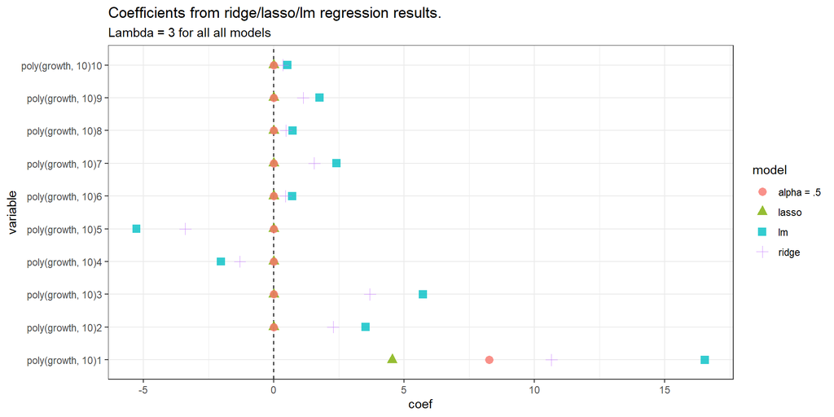

### Elastic net

- In practice, $\lambda$ (and sometimes $\alpha$) will often be set by using cross validation **within** the training data.
- The `cv.glmnet` function will perform this cross validation step automatically, and return some good potential estimates for lambda (although we really would need more data to get anything plausible here)

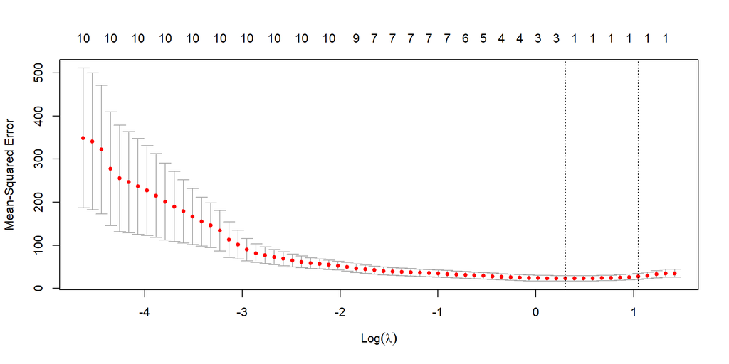

```r
polynomials<- as.matrix(poly(data$growth, 10))



lasso_model<-cv.glmnet(x=polynomials,
                    y= data$vote,
                    alpha= 1, # lasso because alpha = 1
                    family='gaussian')

# show MSE at different values of lambda:
plot(lasso_model)
```

### Elastic net

```r
# lambda that minimized MSE in cross-validation
alpha_model$lambda.min
```

```
[1] 1.866762
```

```r
# lambda min + 1 standard error - slightly more restrictive
alpha_model$lambda.1se
```

```
[1] 6.256646
```

```r
coef(alpha_model, s='lambda.1se')
```

```
11 x 1 sparse Matrix of class "dgCMatrix"
                   s1
(Intercept) 52.055000
1            2.556136
2            .
3            .
4            .
5            .
6            .
7            .
8            .
9            .
10           .
```

```r
# predictions on observed data
predict(alpha_model, s='lambda.1se',
        newx=polynomials)
```

```
      lambda.1se
 [1,]   52.29265
 [2,]   52.52438
 [3,]   51.55961
 [4,]   53.14865
 [5,]   52.58586
 [6,]   52.86962
 [7,]   51.66838
 [8,]   50.97317
 [9,]   52.98312
[10,]   52.23117
[11,]   51.33733
[12,]   51.64946
[13,]   52.27373
[14,]   51.97105
[15,]   51.20491
[16,]   51.60690
```

### Try it out

Create a model to predict `v2lgfemleg`: the % women in the lower house of a country’s Parliament in 2020. Select some variables and compare your prediction results using a regular linear regression vs. an elastic net model.

```r
file_url<-'https://github.com/Neilblund/GVPT728_Winter24/raw/refs/heads/main/Additional%20Code%20and%20Data/vdem_cleaned.rds'

vdem_cleaned<-readRDS(url(file_url))

set.seed(100)
testing<-vdem_cleaned|>
  slice_sample(prop = .2)

training<-vdem_cleaned|>
  anti_join(testing)
```

### Categorical prediction problems

- Metrics like mean-squared error work for continuous outcomes, but we often want to predict categorical responses like “voted” vs “didn’t vote” or “conflict” vs. “no conflict” etc.
- For these problems, we’ll generally need to use different models (although there is a version of the elastic net model for logistic regression!)
- We’ll also need to use different metrics to assess them, because squared errors mostly only make sense in the context of continuous variables.

### Confusion matrices

If I have a binary classifier that spits out predictions of 1 or 0…

| Individual number | 1 | 2 | 3 | 4 | 5 | 6 | 7 | 8 | 9 | 10 | 11 | 12 |
| --- | --- | --- | --- | --- | --- | --- | --- | --- | --- | --- | --- | --- |
| Actual classification | 1 | 1 | 1 | 1 | 1 | 1 | 1 | 1 | 0 | 0 | 0 | 0 |
| Predicted classification | 0 | 0 | 1 | 1 | 1 | 1 | 1 | 1 | 1 | 0 | 0 | 0 |
| Result | FN | FN | TP | TP | TP | TP | TP | TP | FP | TN | TN | TN |

I could think about putting together a cross tab with predictions on one axis and “reality” on the other:

### Confusion matrices

- **Accuracy:** the % of predicted cases that are accurate
- **Precision:** the % of predicted positive cases that were actually positive
- **Recall:** the % of actually positive cases that were predicted positive

|  | Predict Positive (PP) | Predicted Negative (PN) |
| --- | --- | --- |
| Actual Positive (P) | True positive (TP) | False negative (FN) |
| Actual Negative (N) | False positive (FP) | True negative (TN) |

### Confusion matrices

Note that accuracy can be a misleading metric - especially when the classes are unbalanced:

|  | Predicted Positive (PP) | Predicted Negative (PN) |
| --- | --- | --- |
| Actual Positive (P) | 10 | 0 |
| Actual Negative (N) | 5 | 0 |

### Confusion matrices

Some alternative measures for binary classifiers are:

- F-Scores: the harmonic mean of precision and recall: $\frac{2TP}{2TP+FP+FN}$
- Cohen’s Kappa: $\frac{(TP + FP) * (TP + FN) + (FN + TN) * (FP + TN)}{(\text{Total Predictions})^2}$
- Area under the curve (a measure based on evaluating performance across different parameter values)

### Comparing some classifiers

```r
gtd<-read_csv('https://raw.githubusercontent.com/Neilblund/APAN/refs/heads/main/gtd_2020.csv')
codebook<-read_csv("https://raw.githubusercontent.com/Neilblund/APAN/refs/heads/main/included_gtd.csv")
gtd$attack_dummy<-factor(gtd$any_attacks)


set.seed(100)
gtd_testing<-gtd|>
  slice_sample(prop = .2)

gtd_training<-anti_join(gtd, gtd_testing)



dummy_model<-glm(attack_dummy ~ 1, data=gtd_training, family='binomial')
simple_model<-glm(attack_dummy ~ v2peapssoc  , data=gtd_training, family='binomial')
complex_model<-glm(attack_dummy ~ v2peapssoc * v2x_pubcorr  , data=gtd_training, family='binomial')
```

### Comparing some classifiers

Get predicted probabilities using predict with `type='response'`, then make the predictions binary, then create a factor:

```r
probs<-predict(dummy_model, newdata = gtd_testing,  type='response')

cat_pred<-factor(probs>=.5, levels=c(FALSE, TRUE), labels=c("No", "Yes"))
```

Then set up a confusion matrix. The variable will define the rows, the second defines the columns:

```r
table(cat_pred, gtd_testing$attack_dummy)
```

```
cat_pred no yes
     No  19  14
     Yes  0   0
```

### With glmnet:

The approach for glmnet is similar, except we can’t use the formula syntax.

```r
training_features<-model.matrix(~  v2peapssoc * v2x_pubcorr, data=gtd_training)

testing_features<-model.matrix(~  v2peapssoc  * v2x_pubcorr, data=gtd_testing)

training_outcomes<-gtd_training$attack_dummy

testing_outcomes<-gtd_testing$attack_dummy


model_glmnet<-cv.glmnet(y=training_outcomes,  x= training_features,
               family='binomial')


predictions<-predict(model_glmnet, newx=testing_features, type='response', s='lambda.min')

cat_pred<-factor(predictions>=.5, levels=c(FALSE, TRUE), labels=c("No", "Yes"))

table(cat_pred, gtd_testing$attack_dummy)
```

```
cat_pred no yes
     No  16   8
     Yes  3   6
```